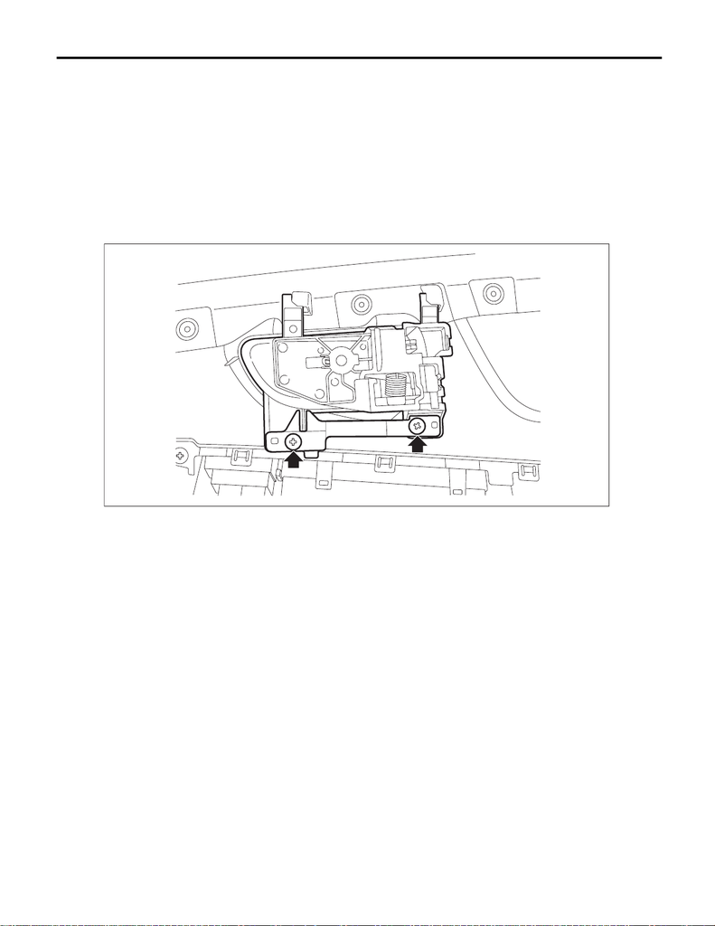

SL-32

Front Inner Remote

SECURITY AND LOCKS

8. Front Inner Remote

A: REMOVAL

NOTE:

For models other than STI model, disconnect the ground terminal from battery sensor.

2) Remove the trim panel - front door. <Ref. to EI-56, FRONT DOOR, REMOVAL, Door Trim.>

CAUTION:

The remote assembly - door is tightened with the plate. Be careful not to drop or damage the part.

B: INSTALLATION

1) Before installation, check the following items.

• Cable is free from deformation such as fray.

• Grease is applied sufficiently to cable joints.

If grease is insufficient, add it as necessary before assembling the cable.

2) Install the remote assembly - door.

CAUTION:

Securely install the plate.

3) Install the trim panel - front door.

4) Connect the battery ground terminal. <Ref. to NT-5, BATTERY, NOTE, Note.>

NOTE:

For models other than STI model, connect the ground terminal to battery sensor.

C: INSPECTION

Check if the remote handle operates normally.

• If the lever is faulty, replace the remote handle.

• If the cable is deformed, replace the latch & actuator assembly - front.

SL-01445